# Lexicon-based Sentiment Analysis

See the code on [github](https://github.com/Barnes7599/sentiment_analysis).

[figure not shown]

#### **Description:**

Sentiment analysis is the study of subjective feelings expressed in text and has recently attracted significant attention from both the research community and industry. As social media, opinions and product reviews continue to influence consumer preferences, more and more companies are seeking ways to determine a consumers attitude towards their products and services.

With all the hype around Elon taking a [9.2% stake](https://www.cnbc.com/2022/04/05/elon-musks-9percent-stake-in-twitter-and-board-seat-heres-what-it-means.html) in twitter and his offer to purchase twitter for [$43 billion](https://www.businessinsider.com/elon-musk-buying-twitter-doesnt-care-economics-trusted-public-platform-2022-4), I thought instead of scrapping reviews or opinions of a company’s products or services, I decided to analyze Elon Musk’s tweets!.

The data was downloaded from NuttySalmon on [GitHub](https://github.com/NuttySalmon). Though the purpose of their repo was to analyze Elon Musk’s Tweets vs Tesla Stock using machine learning algorithms in python, I thought the data would be just as good to conduct a sentiment analysis. Check it out [here](https://github.com/NuttySalmon/Elon-Musk-Tweets-VS-Tesla-Stock).

Let’s get started…

#### **Load Libraries**

Load packages - you may need to install packages using the install.packages() function. Make sure you put the package name in quotes like install.packages(“tidyverse”), you will only have to do this once.

```r
library(tidyverse)
library(lubridate)
library(readxl)
library(showtext)
library(ggtext)
library(glue)
library(tidytext)
library(textdata)
library(ggwordcloud)
```

#### **Add design elements**

I typically will add design elements upfront so that I know what fonts and colors I will be using in the visualizations. We will use the showtext package to read in goggle fonts and I will simply assign hex color codes to 2 color variables. Do not forget to add the showtext_auto() function to tell the code below to use these specific fonts when called.

```r
# Assign color variables
col1 <- "#F1F4CC"
col2 <- "#00293D"

# Adding Google Fonts
font_add_google(family = "patua-one", "Patua One")
font_add_google(family = "montserrat", "Montserrat")

# function used to tell the code below use the above fonts
showtext_auto()
```

#### **Load the data**

Data set is located at: [Here](https://raw.githubusercontent.com/NuttySalmon/Elon-Musk-Tweets-VS-Tesla-Stock/master/tweets.csv)

I typically use the janitor package whenever I read in a data set. it cleans up the column headings by making them all lower case and placing an underscore between spaces. However, this dataset already has nicely structured column headers. Additionally, we will read in stop_words, which is a part of the tidytext package and are common words such as “the”, “and”, “is” etc. We will want to remove these “stop words” from the elon’s tweets.

```r
elon_tweets <- read_csv("https://raw.githubusercontent.com/NuttySalmon/Elon-Musk-Tweets-VS-Tesla-Stock/master/tweets.csv")

data("stop_words")

#Dates
min_date <- min(elon_tweets$date) %>%
  as.Date()

max_date <- max(elon_tweets$date) %>%
  as.Date()
```

One thing to note is that the tweets begin on 2012-01-03 and the last tweet collected in the dataset was on 2020-05-01, 2 months after the COVID pandemic began.

#### **Data Wrangling**

Now that we have loaded in the data we will have to wrangle the data so that it is tidy, which will enable us to easily use tidytext and other packages.

To do this we will use the unnest_tokens() function, this will resturcture the data by parasing each word within the tweet and placing them on their own row, essentially converting each word to an observation. Lastly, we will anit_join() “stop words” so that we remove them from the tidy dataset.

```r
elon_tweets_tidy <- elon_tweets %>%
  select(text, date) %>%
  mutate(tweet = row_number(),
         date = as.Date(date),
         date = ymd(date),
         tweet = row_number()) %>%
  unnest_tokens(word, text) %>%
  anti_join(stop_words, by = "word")
```

#### **Creating Word clouds using ggwordcloud package**

I have always really liked word clouds. They are visual and informative. They use the preattentive attributes of size, color and intensity to differentiate how common a word or phrase is used. Plus, using the the ggwordcloud package, makes them very simple to generate.

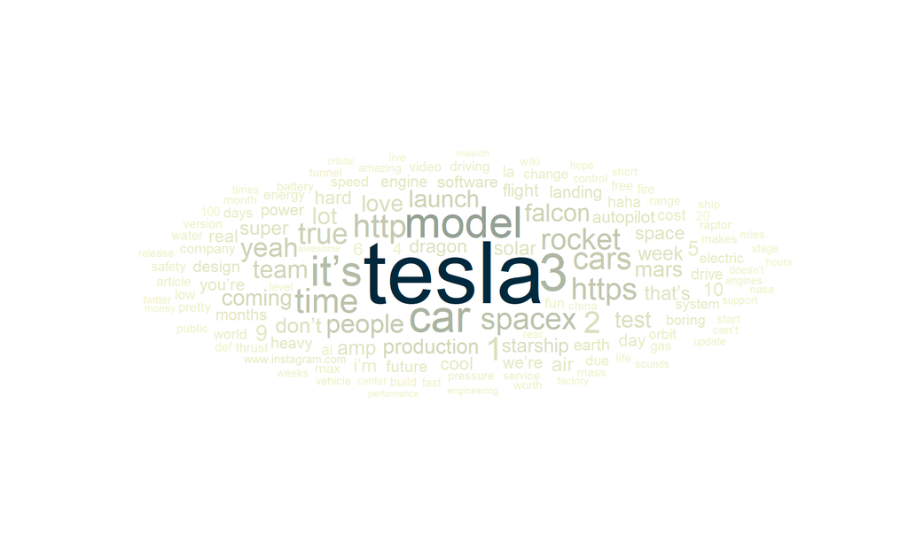

```r
# Load the ggwordcloud package


df <- elon_tweets_tidy %>%
  count(word, sort = TRUE) %>%
  drop_na() %>%
  filter(n > 50)

ggplot(df, aes(
  label = word, size = n,
  color = n
)) +
  geom_text_wordcloud_area(rm_outside = FALSE, max_steps = 1) +
  theme_minimal() +
  scale_size_area(max_size = 24) +
  scale_color_gradient(low = col1, high = col2)
```

#### **Sentiment Analysis**

Let’s create 3 variables on for each lexicon dictionary (Bing, AFINN, NRC) so that we can join the sentiments to our elon_tweet_tidy variable.

```r
# Assign "bing" lexicon to a variable using the get_sentiments() from the tidytext package

bing <- get_sentiments(lexicon = "bing")
afinn <- get_sentiments("afinn")
nrc <- get_sentiments("nrc")


df_bing <- elon_tweets_tidy %>%
  inner_join(bing, by = "word") %>%
  count(date,tweet,sentiment,sort = TRUE) %>%
  spread(key = sentiment, value = n, fill = 0) %>%
  mutate(sentiment = positive - negative,
         method = "Bing")

df_afinn <- elon_tweets_tidy %>%
  inner_join(afinn, by = "word") %>%
  rename(sentiment = value) %>%
  group_by(tweet) %>%
  summarise(sentiment = sum(sentiment)) %>%
  mutate(method = "AFINN")

df_nrc <- elon_tweets_tidy %>%
  inner_join(nrc, by = "word") %>%
  filter(sentiment %in% c("positive", "negative")) %>%
  mutate(method = "NRC") %>%
  count(tweet, sentiment, method) %>%
  pivot_wider(names_from = sentiment, values_from = n, values_fill = 0) %>%
  mutate(sentiment = positive - negative)
```

We will use the same visualization that is presented in [tidytextminnig](https://www.tidytextmining.com/sentiment.html) because it is one of the best ways to see the differences in all three lexicons

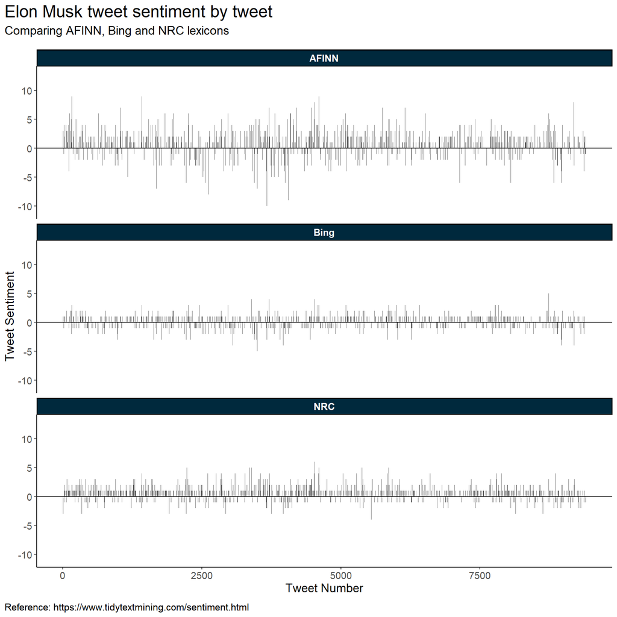

```r
bind_rows(df_bing, df_afinn, df_nrc) %>%
  ggplot(aes(tweet, sentiment)) +
  geom_col() +
  facet_wrap(~method, ncol = 1) +
  geom_hline(yintercept = 0) +
  theme_classic() +
  labs(
    y = "Tweet Sentiment",
    x = "Tweet Number",
    title = "Elon Musk tweet sentiment by tweet",
    subtitle = "Comparing AFINN, Bing and NRC lexicons",
    caption = "Reference: https://www.tidytextmining.com/sentiment.html"
  ) +
  theme(
    text = element_text(
      family = "montserrat",
      size = 14
    ),
    plot.title = element_text(
      family = "patua-one",
      size = 20
    ),
    plot.title.position = "plot",
    plot.subtitle = element_text(margin = margin(b = 15)),
    plot.caption.position = "plot",
    plot.caption = element_text(hjust = 0,
                                margin = margin(t=10)),
    strip.background = element_rect(fill = col2),
    strip.text = element_text(
      color = "white",
      face = "bold",
      family = "patua-one"
    )
  )
```

Pretty cool! You can see that the absolute sentiment values are different among all three lexicons. In our visualization you can clearly see that AFINN has large absolute values as AFINN has a wider scale contributing to higher values.

### **Elon Musk Tweet Sentiment tends to be more positive**

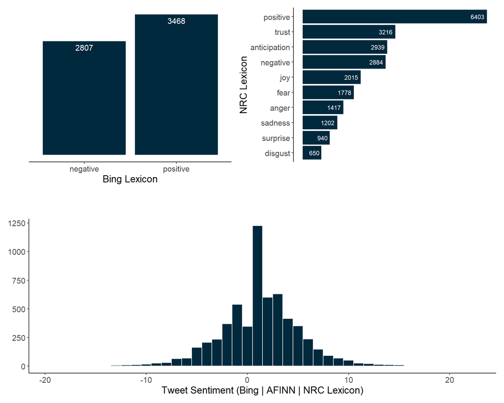

```r
bing_bar <- elon_tweets_tidy %>%
  inner_join(bing, by ="word") %>%
  count(sentiment) %>%
  ggplot(aes(sentiment, n)) +
  geom_col(fill = col2) +
  geom_text(aes(label = n), vjust = 1.5, color = "white", size = 4) +
  theme_classic() +
  labs(
    x = "Bing Lexicon",
    y = NULL,
    title = NULL
  ) +
  theme(
    text = element_text(
      family = "montserrat",
      size = 14
    ),
    plot.title = element_text(
      family = "patua-one",
      size = 20,
      margin = margin(b = 20),
      hjust = .5
    ),
    plot.title.position = "plot",
    axis.text.y = element_blank(),
    axis.ticks.y = element_blank(),
    axis.line.y = element_blank()
  )


nrc_bar <- elon_tweets_tidy %>%
  inner_join(nrc, by ="word") %>%
  count(sentiment) %>%
  ggplot(aes(reorder(sentiment,n),n)) +
  geom_col(fill = col2) +
  geom_text(aes(label = n), vjust = .5, hjust = 1.2, color = "white", size = 3) +
  coord_flip()+
  theme_classic() +
  labs(
    x = "NRC Lexicon",
    y = NULL,
    title = NULL,
  ) +
  theme(
    text = element_text(
      family = "montserrat",
      size = 14
    ),
    plot.title = element_text(
      family = "patua-one",
      size = 20,
      margin = margin(b = 20),
      hjust = .5
    ),
    plot.title.position = "plot",
    axis.line.x = element_blank(),
    axis.text.x = element_blank(),
    axis.ticks.x = element_blank()
  )



total_sentiment <- bind_rows(df_bing,df_afinn,df_nrc) %>%
 group_by(tweet) %>%
  summarise(sentiment = sum(sentiment)) %>%
  ggplot(aes(sentiment)) +
  geom_histogram(fill = col2,color = "white", binwidth = 1) +
     theme_classic() +
  labs(
    x = "Tweet Sentiment (Bing | AFINN | NRC Lexicon)",
    y = NULL,
    title = ""
  ) +
  theme(
    text = element_text(
      family = "montserrat",
      size = 14
    ),
    plot.title = element_text(
      family = "patua-one",
      size = 20,
      margin = margin(b = 20),
      hjust = .5
    ),
    plot.title.position = "plot"
  )

library(patchwork)

(bing_bar|nrc_bar)/total_sentiment
```

So far we have been visualizing Elon Musk’s tweet sentiment by tweet. So let’s take a look at his tweet sentiment over time.

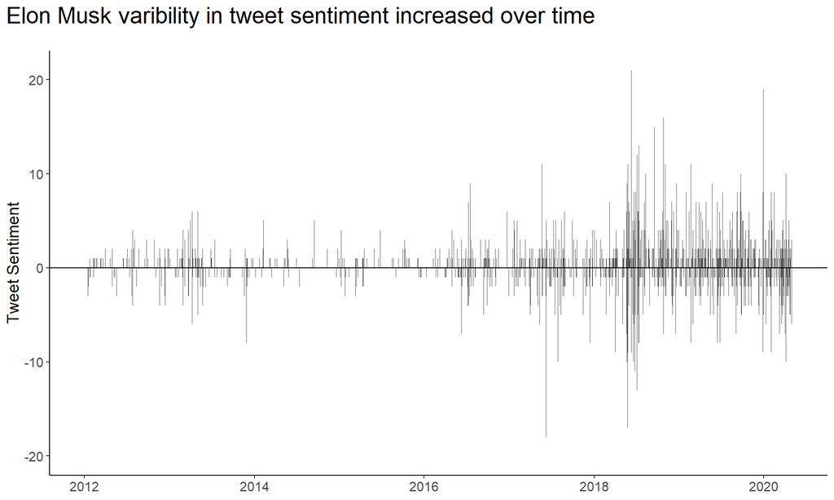

```r
ggplot(
  data = df_bing,
  aes(
    x = date,
    y = sentiment
  ),
) +
  geom_col() +
  geom_hline(yintercept = 0) +
  theme_classic() +
  labs(
    y = "Tweet Sentiment",
    x = NULL,
    title = "Elon Musk varibility in tweet sentiment increased over time"
  ) +
  theme(
    text = element_text(
      family = "montserrat",
      size = 14
    ),
    plot.title = element_text(
      family = "patua-one",
      size = 20,
      margin = margin(b = 20)
    ),
    plot.title.position = "plot"
  )
```

As you can see, sentiment variability in his tweets has grown over time!

### **Let’s visualizes what words appear together most often in Elon’s tweets?**

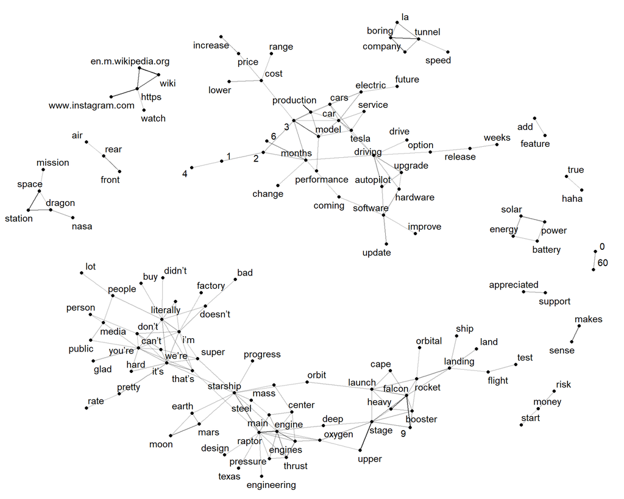

```r
library(tidygraph)
library(ggraph)
library(widyr)

set.seed(1954)

elon_tweets_tidy %>%
  distinct(date, word) %>%
  add_count(word, name = "word_total") %>%
  filter(word_total >= 30) %>%
  pairwise_cor(word, date, sort = TRUE) %>%
  filter(correlation > .2) %>%
  igraph::graph_from_data_frame() %>%
  ggraph(layout = "fr") +
  geom_edge_link(aes(alpha = correlation),
                 show.legend = FALSE) +
  geom_node_point() +
  geom_node_text(aes(label=name),
               repel = TRUE) +
  theme_void()
```

A work by [Jason Barnes](https://github.com/Barnes7599)

*barnes7599@gmail.com*

References: [tidytextmining](https://www.tidytextmining.com/sentiment.html), [AFINN](http://www2.imm.dtu.dk/pubdb/pubs/6010-full.html), [Bing](https://www.cs.uic.edu/~liub/FBS/sentiment-analysis.html), [NRC](http://saifmohammad.com/WebPages/NRC-Emotion-Lexicon.htm)

This work is licensed under a [Creative Commons Attribution-NonCommercial 4.0 International License](http://creativecommons.org/licenses/by-nc/4.0/).